# Zambia MAIZE Forescasts

Dr. -Ing. MISK Benson Kenduiywo

2022-06-30

```r
library(knitr)
opts_chunk$set(tidy.opts = list(width.cutoff = 60))
opts_knit$set(global.par = TRUE)
```

## Reference data

Load Zambia’s ministry of agriculture maize forecasts data as reference.

```r
rm(list = ls(all=TRUE))
unlink(".RData")
root <- "D:/RCMRD/Data/Yields/"
r.file <- paste0(root, "Reference/Zambia_District _Maize_Forecasting_2011_2022.csv")
```

Load data

```r
ref <- read.csv(r.file, stringsAsFactors =  FALSE)
names(ref)
```

```
## [1] "Province"      "District"      "planted_ha"    "harvested_ha"
## [5] "production_MT" "yield_MT_ha"   "Year"
```

Convert District and province names to upper case.

```r
ref$Province <- trimws(toupper(ref$Province), which = c("both"))
sort(unique(ref$Province))
```

```
##  [1] "CENTRAL"       "COPPERBELT"    "EASTERN"       "LUAPULA"
##  [5] "LUSAKA"        "MUCHINGA"      "NORTH-WESTERN" "NORTHERN"
##  [9] "SOUTHERN"      "WESTERN"
```

```r
ref$District <- trimws(toupper(ref$District), which = c("both"))
kable(head(sort(unique(ref$District))), caption="Districts")
```

Districts

| x |
| --- |
| CHADIZA |
| CHAMA |
| CHAVUMA |
| CHIBOMBO |
| CHIENGE |
| CHILILABOMBWE |

Visualize the crop forecasting data from MoA per year.

```r
par(mar=c(2,2,2,2)) #c(bottom, left, top, right)
```

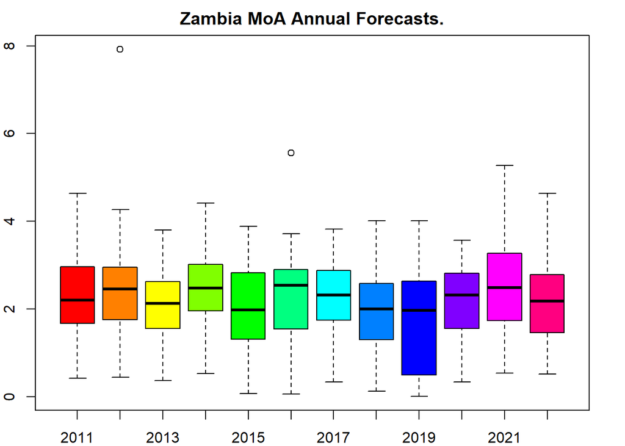

```r
boxplot(yield_MT_ha~Year, data=ref, col=rainbow(length(unique(ref$Year))), xlab="Year", ylab = "Yield (MT/ha)", main="Zambia MoA Annual Forecasts.")
```

Visualize the crop forecasting data from MoA per Province.

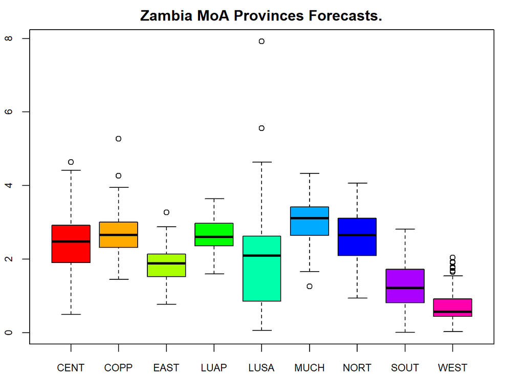

```r
agg <- ref#aggregate(ref[,"yield_MT_ha", drop=FALSE], ref[, c("Province","District","Year"), drop=FALSE], sum, na.rm=TRUE)
agg$Province <- substr(agg$Province,start=1,stop=4)
agg <- na.omit(agg)
boxplot(yield_MT_ha~Province, data=agg, col=rainbow(length(unique(agg$Province))), xlab="Provinces", ylab = "Yield (MT/ha)", main="Zambia MoA Provinces Forecasts.", cex.axis=0.8) #horizontal = T, las=1
```

Aggregate MoA forecasts per district.

```r
ref.agg <- aggregate(ref[,"yield_MT_ha", drop=FALSE], ref[, c("District","Year"), drop=FALSE], mean, na.rm=TRUE)
```

## RHEAS simulated yields

Load and aggregate RHEAS simulated Leaf Area Index (LAI), Water stress and Grain Weight Average Dry (GWAD) across different ensembles. Extract year from dates (we will use harvest year).

```r
tt <- read.csv(paste0(root, "RHEAS/zambia_dssatTable_1990_2022.csv"), stringsAsFactors =  FALSE)
tt$harvest <- as.Date(tt$harvest)
tt$planting <- as.Date(tt$planting)
tt$date <- format(tt$harvest, format = "%Y")
names(tt)[3] <- "District"
tt$District[tt$District=="CHIENGI"] <- "CHIENGE"
tt$District[tt$District=="SHANGOMBO"] <- "SHANG'OMBO"
```

## Production forecast and RHEAS metrics aggregagation

Aggregate RHEAS production forecasts and metrics with respect to Districts maize growing calendar.

The maize growing season in Zambia starts from October to end of June. So we will aggregate the metrics and forecast with this condition using the function `RH_metrics`.

```r
RH_metrics <- function(rh, sStart, sEnd){
  rh <- subset(rh, format(as.Date(rh$planting), "%m") >= sStart & format(as.Date(rh$harvest), "%m") <= sEnd)
  rh <- aggregate(rh[,c("wsgd","lai","gwad")], rh[,c("District","date")], mean, na.rm=T)
  return(rh)
}

rh <- RH_metrics(tt, sStart ="10", sEnd = "06")
```

Convert RHEAS yields from kg/ha to MT/ha.

```r
rh$gwad <- rh$gwad/1000
```

## Visualization

Add shapefile for visualization.

```r
library(raster)
filename <- "D:/Adm data/Zambia/gadm36_ZMB_2.shp"
zmb <- shapefile(filename)
names(zmb)[14] <- "District"
zmb$District[zmb$District=="CHIENGI"] <- "CHIENGE"
zmb$District[zmb$District=="SHANGOMBO"] <- "SHANG'OMBO"
```

Check and format District names to be consistent in both the RHEAS and administrative boundaries.

```r
#RHEAS
c <- sort(unique(rh$District))
c[!c %in% sort(unique(zmb$District))]
```

```
## character(0)
```

```r
#MoA Forecasts
c <- sort(unique(ref$District))
c[!c %in% sort(unique(zmb$District))]
```

```
## [1] "IKELENGE"  "MAFINGA"   "SHANGOMBO"
```

Merge RHEAS and Admin data.

```r
zmb <-  merge(zmb[,"District"], rh[rh$date=="2022",], by = "District")
path <- "D:/RCMRD/Code/yieldprediction"
shapefile(zmb[,c("District", "wsgd", "lai","gwad")], paste0(path,"/zambia/Zambia_Maize_Forecasts.shp"),overwrite=T)
```

Visualize RHEAS predicted yields spatially.

```r
library(tmap)
library(mapview)
tmap_mode("view")
```

```
## tmap mode set to interactive viewing
```

```r
map_a <- tm_shape(zmb, name="Average yield (MT/ha) per District") +
  tm_polygons("gwad", id="gwad",breaks = seq(2,4,0.4),  title="Maize yield (MT/ha) 2022") +
  tm_text("District", size = 0.75)+
  tm_layout(title.size =5, panel.label.size=6)+
  tm_format("World")
map_a
```

[interactive chart not shown]

```r
#lf <- tmap_leaflet(map_a)
#mapshot(lf, file = "D:/RCMRD/Presentations/ISPRS_2022/Yields_2022_MODIS.png")
```

## Planting/Harvest date detection

Lets Evaluate earliest Planting and harvest dates or months over the years according to the model’s detection.

```r
plantHarvest <- function(df, year){
  temp <- subset(df, date==year)
  d <- sort(unique(temp$District))
  mat <- matrix(, nrow = length(d), ncol = 4)
  for(i in 1:length(d)){
    dist <- subset(temp, District=d[i])
    dist$planting <- as.character(dist$planting)
    dist$harvest <- as.character(dist$harvest)
    p1 <- min(dist$planting)
    p2 <- max(dist$planting)
    h1 <- min(dist$harvest)
    h2 <- max(dist$harvest)
    mat[i, ] <- c(p1,p2,h1,h2)
  }
  #row.names(mat) <- sort(unique(temp$District))
  mat <- as.data.frame(mat)
  mat$District <- sort(unique(temp$District))
  names(mat)[1] <- "Plant_Early"
  names(mat)[2] <- "Plant_Late"
  names(mat)[3] <- "Harvest_Early"
  names(mat)[4] <- "Harvest_Late"
  return(mat)
}

temp <- plantHarvest(tt, 2022)
kable(head(temp))
```

| Plant_Early | Plant_Late | Harvest_Early | Harvest_Late | District |
| --- | --- | --- | --- | --- |
| 2021-11-05 | 2022-02-20 | 2022-02-24 | 2022-05-30 | CHADIZA |
| 2021-11-05 | 2022-02-20 | 2022-02-24 | 2022-05-30 | CHAMA |
| 2021-11-05 | 2022-02-20 | 2022-02-24 | 2022-05-30 | CHAVUMA |
| 2021-11-05 | 2022-02-20 | 2022-02-24 | 2022-05-30 | CHIBOMBO |
| 2021-11-05 | 2022-02-20 | 2022-02-24 | 2022-05-30 | CHIENGE |
| 2021-11-05 | 2022-02-20 | 2022-02-24 | 2022-05-30 | CHILUBI |

## Validation

Compare RHEAS with MoA forecasts.

First check consistency in Districts names.

```r
c <- sort(unique(rh$District))
c[!c %in% sort(unique(ref.agg$District))]
```

```
## character(0)
```

Merge the MoA forecasts with RHEAS ones by year and District.

```r
baseYear <- 2011
x <- rh[rh$date>=baseYear,]
names(x)[2] <- "Year"
y <- ref.agg[ref.agg$Year>=baseYear,]
dff <-  merge(x,y, by = c("District", "Year"))
```

Plot RHEAS forecast versus MoA forecasts.

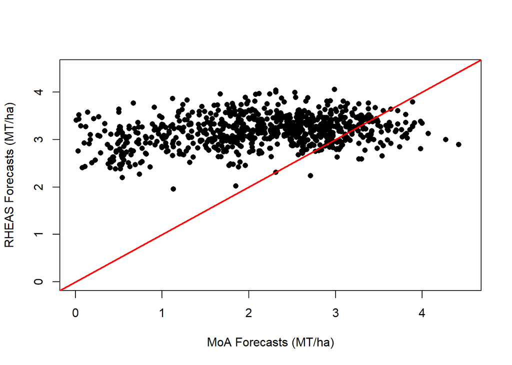

```r
dff <- dff[dff$yield_MT_ha <=4.5,]
x11()
plot(gwad~yield_MT_ha, data=dff, pch=16, xlim = c(0,4.5), ylim = c(0,4.5), xlab="MoA Forecasts (MT/ha)", ylab="RHEAS Forecasts (MT/ha)")
abline(0,1, lwd=2, col="red")
```

Plot the two datasets trends.

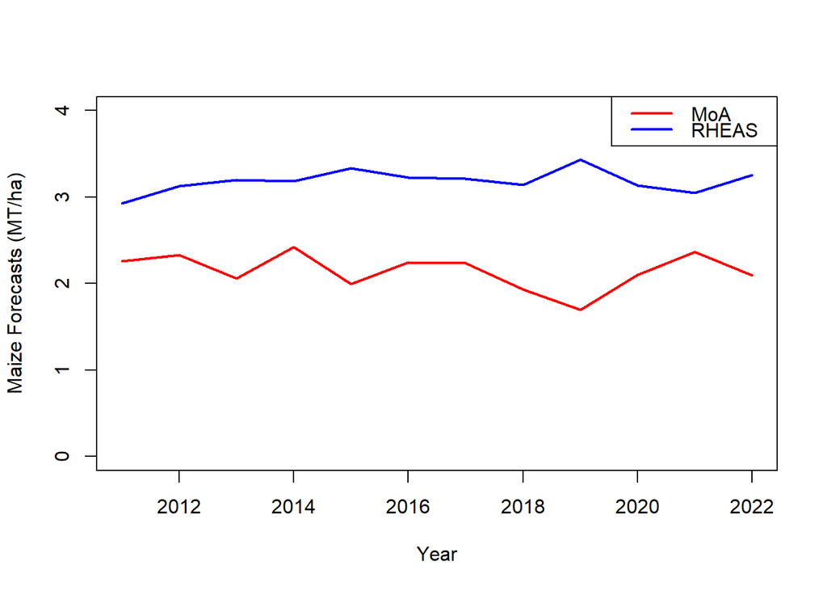

```r
dff.agg <- aggregate(dff[,c("yield_MT_ha", "gwad"), drop=FALSE], dff[, "Year", drop=FALSE], mean, na.rm=TRUE)

x11()
plot(dff.agg$Year, dff.agg$yield_MT_ha, type="l", lwd=2, col="red", ylim = c(0,4), ylab="Maize Forecasts (MT/ha)", xlab="Year")
lines(dff.agg$Year, dff.agg$gwad, col="blue", lwd=2)
legend("topright", c("MoA", "RHEAS"), col=c("red","blue"), lty = 1, lwd=2)
```

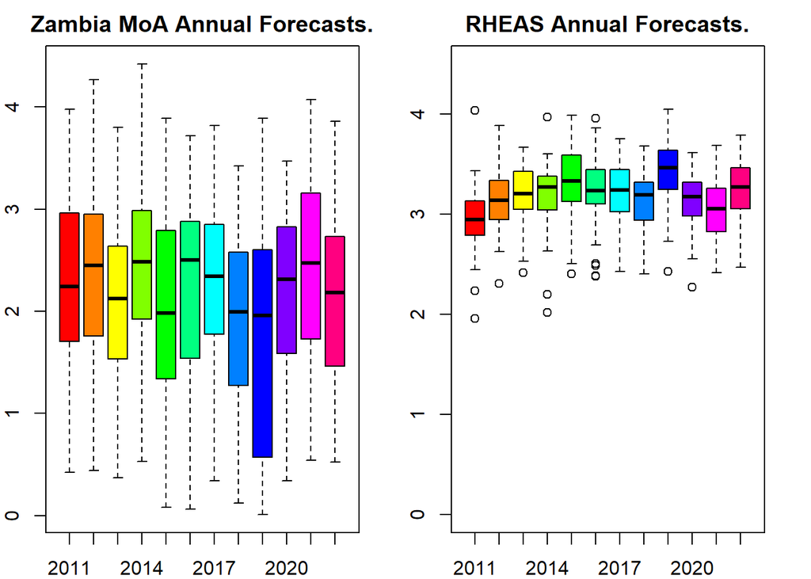

```r
par(mfrow=c(1,2))
dff$District <- substr(dff$District, start=1,stop=3)
boxplot(yield_MT_ha~Year, data=dff, col=rainbow(length(unique(ref$Year))), xlab="Year", ylab = "Yield (MT/ha)", main="Zambia MoA Annual Forecasts.")

boxplot(gwad~Year, data=dff, col=rainbow(length(unique(ref$Year))), xlab="Year", ylab = "Yield (MT/ha)", ylim=c(0,4.5), main="RHEAS Annual Forecasts.")
```

```r
rmse <- function(error){
  sqrt(mean(error^2))
}
```

Compute RMSE.

```r
rmse(dff$gwad-dff$yield_MT_ha)
```

```
## [1] 1.368354
```